# 2: Regression and model validation

*Describe the work you have done this week and summarize your learning.*

- Describe your work and results clearly.
- Assume the reader has an introductory course level understanding of writing and reading R code as well as statistical methods.
- Assume the reader has no previous knowledge of your data or the more advanced methods you are using.

## Step 1: Data wrangling

### 1.1: Install required packages

- To make data retrievals more fluent, we can use the Here package to make setting file paths easy.
- “Here” eliminates the need of setting precise file pathways for data retrieval or saving, as it automatically looks for the designated file in its “starting point path”, by default the current working directory, viewable by command here().

```r
if (!require(here) == T) {
  install.packages("here") #Checks if the package is NOT installed. If this evaluates to TRUE, runs installation.
}
library(here)


if (!require(tidyverse) == T) {
  install.packages("tidyverse")
}
library(tidyverse)

if (!require(GGally) == T) {
  install.packages("GGally")
}
library(GGally)
```

### 1.2 Run the script “create_learning2014.R”

- The required data set, learning 2014, is downloaded and edited in a separate script.
- Package “here” automatically looks for the file in the path specified in here(), which defaults to the current project work directory.

## Step 2: Analysis phase

### 2.1 Graphical summary of the variables

- First off, we produce a faceted plot of all variables.

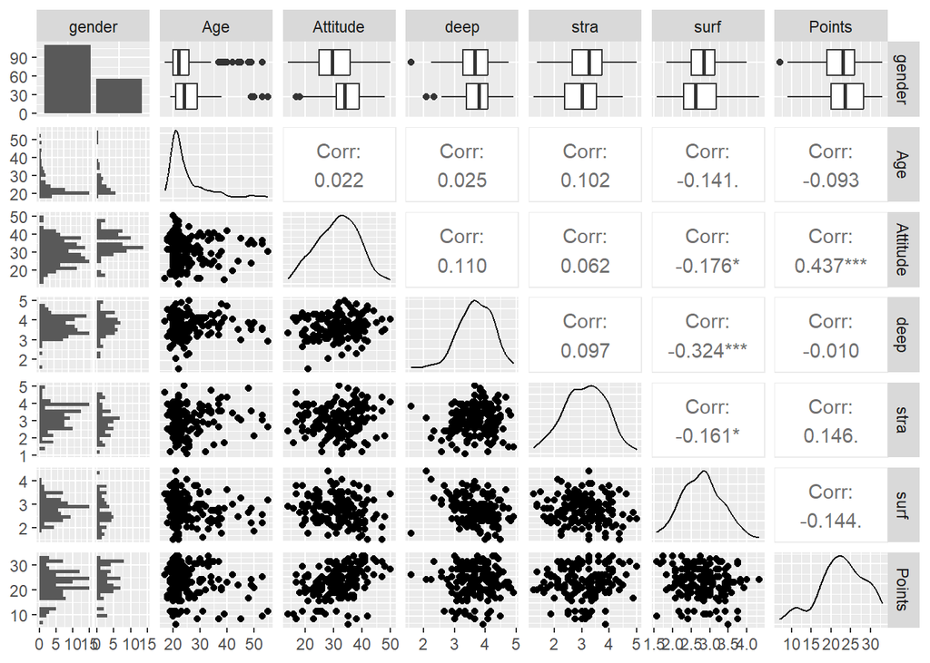

```r
ggpairs(Data, mapping = aes(), lower = list(combo = wrap("facethist", bins = 20)))
```

#### Commentary

- Considerably skewed gender distribution.
  - Excact values 110 female, 56 male.
- No immediately obvious patterns or clustering can be seen in the scatter plots.
  - Except maybe for column 2. In these plots, majority of data points cluster to the left (towards low values).
- Multiple statistically significant correlations are evident in the data.
- Variables “Age” and “surf” appear to correlate negatively. We see a slight statistical significance for it as well ( . = significance threshold 0.1)
- Distribution of “Age” is strongly skewed towards low values (see lineplot at intersection Age x Age)
  - Mostly people on the younger side are represented in the data.
- Attitude and Points correlate positively and show a high significance level.
  - Strongest positive correlation coefficient that the data has.
- Variables “surf” and “deep” likewise correlate strongly, but in a different direction (negative coefficient)
  - Their correlation is the strongest negative one seen in the data.,

### 2.2 Simple linear regression

- For this task, we create a model that attempts to explain variation in points by the values of deep learning, attitude and age.

```r
x<-lm(Points ~ deep+Attitude+Age, data = Data) #Create model, assign a name "x" to it
summary(x)
```

```
##
## Call:
## lm(formula = Points ~ deep + Attitude + Age, data = Data)
##
## Residuals:
##     Min      1Q  Median      3Q     Max
## -17.206  -3.430   0.204   3.979  10.950
##
## Coefficients:
##             Estimate Std. Error t value Pr(>|t|)
## (Intercept) 15.60773    3.38966   4.605 8.32e-06 ***
## deep        -0.60275    0.75031  -0.803    0.423
## Attitude     0.35941    0.05696   6.310 2.56e-09 ***
## Age         -0.07716    0.05322  -1.450    0.149
## ---
## Signif. codes:  0 '***' 0.001 '**' 0.01 '*' 0.05 '.' 0.1 ' ' 1
##
## Residual standard error: 5.307 on 162 degrees of freedom
## Multiple R-squared:  0.2043, Adjusted R-squared:  0.1896
## F-statistic: 13.87 on 3 and 162 DF,  p-value: 4.305e-08
```

#### Commentary

- Just one variable, attitude, had a statistically significant relationship with Points.
- Next, we refine the model by removing the 2 nonsignificant variables
- Can these two be purged from the model, without suffering a loss in explanatory power?

### Model version 2 (removal of the non-significant explanatory variables)

```r
z<-lm(Points ~ Attitude, data = Data) #Create model, assign a name "x" to it
summary(z)
```

```
##
## Call:
## lm(formula = Points ~ Attitude, data = Data)
##
## Residuals:
##      Min       1Q   Median       3Q      Max
## -16.9763  -3.2119   0.4339   4.1534  10.6645
##
## Coefficients:
##             Estimate Std. Error t value Pr(>|t|)
## (Intercept) 11.63715    1.83035   6.358 1.95e-09 ***
## Attitude     0.35255    0.05674   6.214 4.12e-09 ***
## ---
## Signif. codes:  0 '***' 0.001 '**' 0.01 '*' 0.05 '.' 0.1 ' ' 1
##
## Residual standard error: 5.32 on 164 degrees of freedom
## Multiple R-squared:  0.1906, Adjusted R-squared:  0.1856
## F-statistic: 38.61 on 1 and 164 DF,  p-value: 4.119e-09
```

- Fit remains at about the same ballpark, ca. 20 %, despite the removal of the two other variables.
  - This single variable explains the variation in the data just as well, despite being simpler than the first.
- P value indicates the likelihood of obtaining a similar result as seen, assuming that the null hypotesis is true (in our case, h0 would be something like: “No relationship exists between attitude and points”)
  - Low P lends support to the idea that we can reject h0.
  - Here, P is lower than 0.001 -> strong support for rejecting h0.
- “Estimate” shows regression coefficients, that indicate how severe the relation is (simply put, bigger value = steeper slope).
  - When the value of attitude increases by 1 unit, response variable increases by 0.35
- Model fit parameters (R2) indicate a rather poor fit (circa 20%). R2 indicates, how well or badly the fitted model suits the data. Poor fit may result, if we attempt to describe a non-linear relationship using a linear model…
  - Attitude explains circa 1/5 of the variation in Points.